# Biostat 203B Homework 5

Due Mar 22 @ 11:59PM

Author

Xier Lu UID:206331941

## Predicting ICU duration

Using the ICU cohort `mimiciv_icu_cohort.rds` you built in Homework 4, develop at least three machine learning approaches (logistic regression with enet regularization, random forest, boosting, SVM, MLP, etc) plus a model stacking approach for predicting whether a patient’s ICU stay will be longer than 2 days. You should use the `los_long` variable as the outcome. You algorithms can use patient demographic information (gender, age at ICU `intime`, marital status, race), ICU admission information (first care unit), the last lab measurements before the ICU stay, and first vital measurements during ICU stay as features. You are welcome to use any feature engineering techniques you think are appropriate; but make sure to not use features that are not available at an ICU stay’s `intime`. For instance, `last_careunit` cannot be used in your algorithms.

1. Data preprocessing and feature engineering.
2. Partition data into 50% training set and 50% test set. Stratify partitioning according to `los_long`. For grading purpose, sort the data by `subject_id`, `hadm_id`, and `stay_id` and use the seed `203` for the initial data split. Below is the sample code.

```r
set.seed(203)

# sort
mimiciv_icu_cohort <- mimiciv_icu_cohort |>
  arrange(subject_id, hadm_id, stay_id)

data_split <- initial_split(
  mimiciv_icu_cohort,
  # stratify by los_long
  strata = "los_long",
  prop = 0.5
  )
```

3. Train and tune the models using the training set.
4. Compare model classification performance on the test set. Report both the area under ROC curve and accuracy for each machine learning algorithm and the model stacking. Interpret the results. What are the most important features in predicting long ICU stays? How do the models compare in terms of performance and interpretability?

####Answer

```r
# eval: true
library(GGally)
library(gtsummary)
library(tidyverse)
library(tidymodels)
library(dplyr)
library(mlr3tuning)
library(rsample)
library(keras)
library(ranger)
library(stacks)

mimiciv_icu_cohort <- read_rds("mimiciv_shiny/mimic_icu_cohort.rds") %>%
  arrange(subject_id, hadm_id, stay_id) %>%
  mutate(los_long = as.factor(los_long),
         gender = as.factor(gender),
         respiratory_rate = as.numeric(respiratory_rate),
         non_invasive_blood_pressure_diatolic = as.numeric(non_invasive_blood_pressure_diatolic),
         temperature_f = as.numeric(temperature_f),
         non_invasive_blood_pressure_systolic = as.numeric(non_invasive_blood_pressure_systolic),
         heart_rate = as.numeric(heart_rate)) %>%
  select(-los, -dod, -discharge_location, -hospital_expire_flag)

print(mimiciv_icu_cohort)
```

```
# A tibble: 73,181 × 26
   subject_id  hadm_id  stay_id first_careunit admission_type admission_location
        <int>    <int>    <int> <fct>          <fct>          <fct>
 1   10000032 29079034 39553978 Medical Inten… EW EMER.       EMERGENCY ROOM
 2   10000980 26913865 39765666 Medical Inten… EW EMER.       EMERGENCY ROOM
 3   10001217 24597018 37067082 Surgical Inte… EW EMER.       EMERGENCY ROOM
 4   10001217 27703517 34592300 Surgical Inte… Other          PHYSICIAN REFERRAL
 5   10001725 25563031 31205490 Medical/Surgi… EW EMER.       Other
 6   10001884 26184834 37510196 Medical Inten… OBSERVATION A… EMERGENCY ROOM
 7   10002013 23581541 39060235 Cardiac Vascu… SURGICAL SAME… PHYSICIAN REFERRAL
 8   10002155 20345487 32358465 Medical Inten… EW EMER.       EMERGENCY ROOM
 9   10002155 23822395 33685454 Other          EW EMER.       Other
10   10002155 28994087 31090461 Medical/Surgi… EW EMER.       EMERGENCY ROOM
# ℹ 73,171 more rows
# ℹ 20 more variables: insurance <chr>, language <chr>, marital_status <chr>,
#   race <fct>, gender <fct>, age_at_intime <int>, creatinine <dbl>,
#   sodium <dbl>, bicarbonate <dbl>, hematocrit <dbl>, glucose <dbl>,
#   wbc <dbl>, potassium <dbl>, chloride <dbl>,
#   non_invasive_blood_pressure_diatolic <dbl>, respiratory_rate <dbl>,
#   temperature_f <dbl>, heart_rate <dbl>, …
```

```r
mimiciv_icu_cohort <- mimiciv_icu_cohort %>%
  select(-3, -2, -1)

colnames(mimiciv_icu_cohort)
```

```
 [1] "first_careunit"
 [2] "admission_type"
 [3] "admission_location"
 [4] "insurance"
 [5] "language"
 [6] "marital_status"
 [7] "race"
 [8] "gender"
 [9] "age_at_intime"
[10] "creatinine"
[11] "sodium"
[12] "bicarbonate"
[13] "hematocrit"
[14] "glucose"
[15] "wbc"
[16] "potassium"
[17] "chloride"
[18] "non_invasive_blood_pressure_diatolic"
[19] "respiratory_rate"
[20] "temperature_f"
[21] "heart_rate"
[22] "non_invasive_blood_pressure_systolic"
[23] "los_long"
```

```r
print(mimiciv_icu_cohort)
```

```
# A tibble: 73,181 × 23
   first_careunit           admission_type admission_location insurance language
   <fct>                    <fct>          <fct>              <chr>     <chr>
 1 Medical Intensive Care … EW EMER.       EMERGENCY ROOM     Medicaid  ENGLISH
 2 Medical Intensive Care … EW EMER.       EMERGENCY ROOM     Medicare  ENGLISH
 3 Surgical Intensive Care… EW EMER.       EMERGENCY ROOM     Other     ?
 4 Surgical Intensive Care… Other          PHYSICIAN REFERRAL Other     ?
 5 Medical/Surgical Intens… EW EMER.       Other              Other     ENGLISH
 6 Medical Intensive Care … OBSERVATION A… EMERGENCY ROOM     Medicare  ENGLISH
 7 Cardiac Vascular Intens… SURGICAL SAME… PHYSICIAN REFERRAL Medicare  ENGLISH
 8 Medical Intensive Care … EW EMER.       EMERGENCY ROOM     Other     ENGLISH
 9 Other                    EW EMER.       Other              Other     ENGLISH
10 Medical/Surgical Intens… EW EMER.       EMERGENCY ROOM     Other     ENGLISH
# ℹ 73,171 more rows
# ℹ 18 more variables: marital_status <chr>, race <fct>, gender <fct>,
#   age_at_intime <int>, creatinine <dbl>, sodium <dbl>, bicarbonate <dbl>,
#   hematocrit <dbl>, glucose <dbl>, wbc <dbl>, potassium <dbl>,
#   chloride <dbl>, non_invasive_blood_pressure_diatolic <dbl>,
#   respiratory_rate <dbl>, temperature_f <dbl>, heart_rate <dbl>,
#   non_invasive_blood_pressure_systolic <dbl>, los_long <fct>
```

#####Classification Trees

```r
# eval: true
mimiciv_icu_cohort1 <- mimiciv_icu_cohort
# Data split
data_split <- initial_split(
  mimiciv_icu_cohort,
  strata = "los_long",
  prop = 0.5
)

mimiciv_other <- training(data_split)
mimiciv_test <- testing(data_split)
```

#####classiciation tree

```r
# eval: true
# Preprocessing
mimic_recipe <-
  recipe(
    los_long ~ .,
    data = mimiciv_other
  ) %>%
  step_impute_mean(
sodium, chloride, creatinine, potassium, glucose, hematocrit, wbc, bicarbonate, temperature_f,
non_invasive_blood_pressure_systolic, respiratory_rate, heart_rate, age_at_intime) %>%
  step_impute_mode(first_careunit, admission_type, admission_location, insurance, language, marital_status,
                   race, gender) %>%
  step_naomit(all_predictors()) %>%
  step_novel(all_nominal_predictors()) %>%
  step_dummy(all_nominal_predictors()) %>%
  step_zv(all_numeric_predictors()) %>%
  step_normalize(all_numeric_predictors())


# Fit the model
classtree_mod <- decision_tree(
  cost_complexity = tune(),
  tree_depth = tune(),
  min_n = 5,
  mode = "classification",
  engine = "rpart"
  )

tree_wf <- workflow() %>%
  add_recipe(mimic_recipe) %>%
  add_model(classtree_mod)

# Tune the model
tree_grid <- grid_regular(cost_complexity(),
                          tree_depth(),
                          levels = c(100,5))


# Cross-validation (CV)
set.seed(203)
folds <- vfold_cv(mimiciv_other, v = 5)

tree_fit <- tree_wf %>%
  tune_grid(
    resamples = folds,
    grid = tree_grid,
    metrics = metric_set(accuracy, roc_auc),
    control = control_stack_grid()
    )
```

```
ℹ The workflow being saved contains a recipe, which is 5.53 Mb in ℹ memory. If
this was not intentional, please set the control setting ℹ `save_workflow =
FALSE`.
```

```
# A tibble: 1,000 × 8
   cost_complexity tree_depth .metric  .estimator  mean     n std_err
             <dbl>      <int> <chr>    <chr>      <dbl> <int>   <dbl>
 1        1   e-10          1 accuracy binary     0.551     5 0.00435
 2        1   e-10          1 roc_auc  binary     0.539     5 0.00289
 3        1.23e-10          1 accuracy binary     0.551     5 0.00435
 4        1.23e-10          1 roc_auc  binary     0.539     5 0.00289
 5        1.52e-10          1 accuracy binary     0.551     5 0.00435
 6        1.52e-10          1 roc_auc  binary     0.539     5 0.00289
 7        1.87e-10          1 accuracy binary     0.551     5 0.00435
 8        1.87e-10          1 roc_auc  binary     0.539     5 0.00289
 9        2.31e-10          1 accuracy binary     0.551     5 0.00435
10        2.31e-10          1 roc_auc  binary     0.539     5 0.00289
   .config
   <chr>
 1 Preprocessor1_Model001
 2 Preprocessor1_Model001
 3 Preprocessor1_Model002
 4 Preprocessor1_Model002
 5 Preprocessor1_Model003
 6 Preprocessor1_Model003
 7 Preprocessor1_Model004
 8 Preprocessor1_Model004
 9 Preprocessor1_Model005
10 Preprocessor1_Model005
# ℹ 990 more rows
```

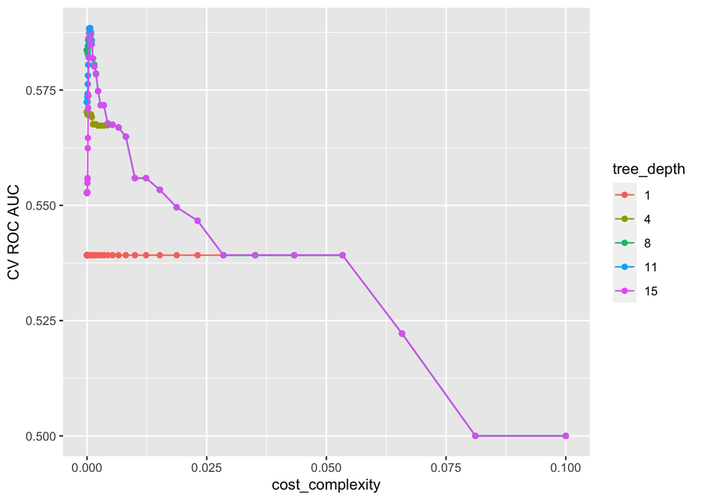

```r
tree_fit %>%
  collect_metrics() %>%
  print(width = Inf) %>%
  filter(.metric == "roc_auc") %>%
  mutate(tree_depth = as.factor(tree_depth)) %>%
  ggplot(mapping = aes(x = cost_complexity, y = mean, color = tree_depth)) +
  geom_point() +
  geom_line() +
  labs(x = "cost_complexity", y = "CV ROC AUC", color = "tree_depth")
```

```r
# Final model
tree_fit %>%
  show_best("roc_auc")
```

```
# A tibble: 5 × 8
  cost_complexity tree_depth .metric .estimator  mean     n std_err .config
            <dbl>      <int> <chr>   <chr>      <dbl> <int>   <dbl> <chr>
1        0.000658         11 roc_auc binary     0.588     5 0.00272 Preprocesso…
2        0.000433         11 roc_auc binary     0.588     5 0.00224 Preprocesso…
3        0.000811         11 roc_auc binary     0.588     5 0.00307 Preprocesso…
4        0.000433          8 roc_auc binary     0.587     5 0.00283 Preprocesso…
5        0.000534         11 roc_auc binary     0.587     5 0.00253 Preprocesso…
```

```r
best_tree <- tree_fit %>%
  select_best("roc_auc")

final_wf <- tree_wf %>%
  finalize_workflow(best_tree)

final_fit <-
  final_wf %>%
  last_fit(data_split)

final_fit %>%
  collect_metrics()
```

```
# A tibble: 2 × 4
  .metric  .estimator .estimate .config
  <chr>    <chr>          <dbl> <chr>
1 accuracy binary         0.572 Preprocessor1_Model1
2 roc_auc  binary         0.587 Preprocessor1_Model1
```

```r
library(rpart.plot)
final_tree <- extract_workflow(final_fit)
final_tree
```

```
══ Workflow [trained] ══════════════════════════════════════════════════════════
Preprocessor: Recipe
Model: decision_tree()

── Preprocessor ────────────────────────────────────────────────────────────────
7 Recipe Steps

• step_impute_mean()
• step_impute_mode()
• step_naomit()
• step_novel()
• step_dummy()
• step_zv()
• step_normalize()

── Model ───────────────────────────────────────────────────────────────────────
n= 36109

node), split, n, loss, yval, (yprob)
      * denotes terminal node

   1) root 36109 17444 FALSE (0.5169071 0.4830929)
     2) admission_location_TRANSFER.FROM.HOSPITAL< 0.6939641 28348 12985 FALSE (0.5419430 0.4580570)
       4) non_invasive_blood_pressure_systolic>=-0.3350976 23321 10272 FALSE (0.5595386 0.4404614)
         8) respiratory_rate< 0.7143426 18663  7842 FALSE (0.5798103 0.4201897)
          16) temperature_f< 0.2576173 15216  6133 FALSE (0.5969374 0.4030626)
            32) age_at_intime< -0.3151331 5212  1842 FALSE (0.6465848 0.3534152) *
            33) age_at_intime>=-0.3151331 10004  4291 FALSE (0.5710716 0.4289284)
              66) wbc< -0.2890196 4517  1790 FALSE (0.6037193 0.3962807)
               132) temperature_f>=-0.6409956 4191  1619 FALSE (0.6136960 0.3863040)
                 264) sodium< 2.334314 4173  1603 FALSE (0.6158639 0.3841361)
                   528) non_invasive_blood_pressure_diatolic>=-0.07352046 4100  1559 FALSE (0.6197561 0.3802439) *
                   529) non_invasive_blood_pressure_diatolic< -0.07352046 73    29 TRUE (0.3972603 0.6027397) *
                 265) sodium>=2.334314 18     2 TRUE (0.1111111 0.8888889) *
               133) temperature_f< -0.6409956 326   155 TRUE (0.4754601 0.5245399)
                 266) non_invasive_blood_pressure_diatolic>=0.009572809 84    31 FALSE (0.6309524 0.3690476) *
                 267) non_invasive_blood_pressure_diatolic< 0.009572809 242   102 TRUE (0.4214876 0.5785124) *
              67) wbc>=-0.2890196 5487  2501 FALSE (0.5441954 0.4558046)
               134) hematocrit>=-0.739331 4279  1882 FALSE (0.5601776 0.4398224)
                 268) race_Other< 0.9937554 3745  1604 FALSE (0.5716956 0.4283044) *
```

[output cut: 14 more lines]

```
                    1083) first_careunit_Medical.Intensive.Care.Unit..MICU.< 0.6752336 737   333 TRUE (0.4518318 0.5481682)
                      2166) hematocrit< -1.492763 223   100 FALSE (0.5515695 0.4484305) *
                      2167) hematocrit>=-1.492763 514   210 TRUE (0.4085603 0.5914397) *
                 271) sodium>=1.525915 50    14 TRUE (0.2800000 0.7200000) *
          17) temperature_f>=0.2576173 3447  1709 FALSE (0.5042066 0.4957934)
            34) creatinine< -0.08769557 2529  1208 FALSE (0.5223408 0.4776592)
              68) bicarbonate< 1.934041 2446  1154 FALSE (0.5282093 0.4717907)
               136) chloride< 1.747657 2384  1112 FALSE (0.5335570 0.4664430)
                 272) age_at_intime< -1.38132 406   162 FALSE (0.6009852 0.3990148) *
                 273) age_at_intime>=-1.38132 1978   950 FALSE (0.5197169 0.4802831)
                   546) creatinine>=-0.5894764 1834   863 FALSE (0.5294438 0.4705562)
                    1092) glucose< -0.566426 271   104 FALSE (0.6162362 0.3837638) *

...
and 76 more lines.
```

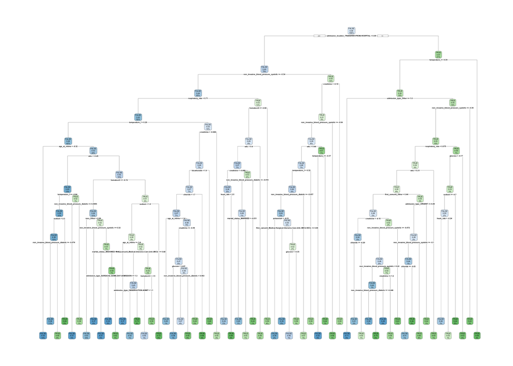

```r
final_tree %>%
  extract_fit_engine() %>%
  rpart.plot(roundint = FALSE)
```

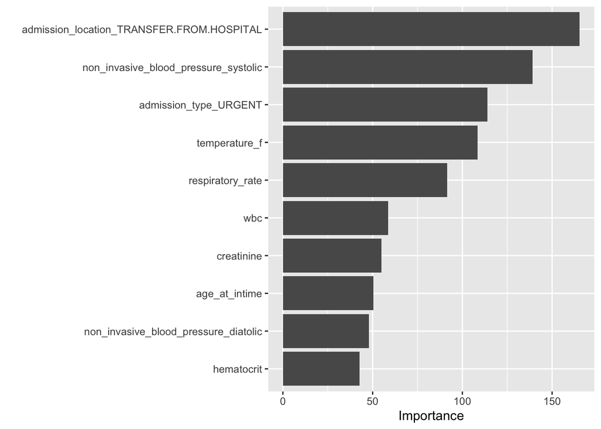

```r
library(vip)
final_tree %>%
  extract_fit_parsnip() %>%
  vip()
```

The image shows a table with performance metrics for a binary classification model referred to as “Preprocessor1_Model1.” This model has achieved an accuracy of approximately 0.57, which means it accurately predicts the correct class for the binary target variable about 57% of the time. The model also has an ROC AUC (Receiver Operating Characteristic - Area Under Curve) of about 0.59, which indicates its ability to distinguish between the two classes is slightly better than random chance but still indicates room for improvement.

#####random forest

```r
# eval: true
# Preprocessing
mimic_recipe <-
  recipe(
    los_long ~ .,
    data = mimiciv_other
  ) %>%
  step_impute_mean(
sodium, chloride, creatinine, potassium, glucose, hematocrit, wbc, bicarbonate, temperature_f,
non_invasive_blood_pressure_diatolic, non_invasive_blood_pressure_systolic, respiratory_rate, heart_rate,
age_at_intime) %>%
  step_impute_mode(first_careunit, admission_type, admission_location, insurance, language, marital_status,
                   race, gender) %>%
  step_naomit(all_predictors()) %>%
  step_novel(all_nominal_predictors()) %>%
  step_dummy(all_nominal_predictors()) %>%
  step_zv(all_numeric_predictors()) %>%
  step_normalize(all_numeric_predictors())

# Fit the model
rf_mod <- rand_forest(
  mode = "classification",
  mtry = tune(),
  trees = tune()
) %>%
set_engine("ranger")

rf_wf <- workflow() %>%
  add_recipe(mimic_recipe) %>%
  add_model(rf_mod)

param_grid <- grid_regular(
  mtry(range = c(1L, 5L)),
  trees(range = c(100L, 300L)),
  levels = c(3, 5)
)

# Cross-validation (CV)
set.seed(203)
folds <- vfold_cv(mimiciv_other, v = 5)

rf_fit <- rf_wf %>%
  tune_grid(
    resamples = folds,
    grid = param_grid,
    metrics = metric_set(roc_auc, accuracy),
    control = control_stack_grid()
  )
```

```
ℹ The workflow being saved contains a recipe, which is 5.53 Mb in ℹ memory. If
this was not intentional, please set the control setting ℹ `save_workflow =
FALSE`.
```

```
# A tibble: 30 × 8
    mtry trees .metric  .estimator  mean     n std_err .config
   <int> <int> <chr>    <chr>      <dbl> <int>   <dbl> <chr>
 1     1   100 accuracy binary     0.586     5 0.00343 Preprocessor1_Model01
 2     1   100 roc_auc  binary     0.632     5 0.00331 Preprocessor1_Model01
 3     3   100 accuracy binary     0.599     5 0.00301 Preprocessor1_Model02
 4     3   100 roc_auc  binary     0.637     5 0.00323 Preprocessor1_Model02
 5     5   100 accuracy binary     0.598     5 0.00346 Preprocessor1_Model03
 6     5   100 roc_auc  binary     0.637     5 0.00362 Preprocessor1_Model03
 7     1   150 accuracy binary     0.587     5 0.00387 Preprocessor1_Model04
 8     1   150 roc_auc  binary     0.634     5 0.00391 Preprocessor1_Model04
 9     3   150 accuracy binary     0.601     5 0.00353 Preprocessor1_Model05
10     3   150 roc_auc  binary     0.640     5 0.00377 Preprocessor1_Model05
# ℹ 20 more rows
```

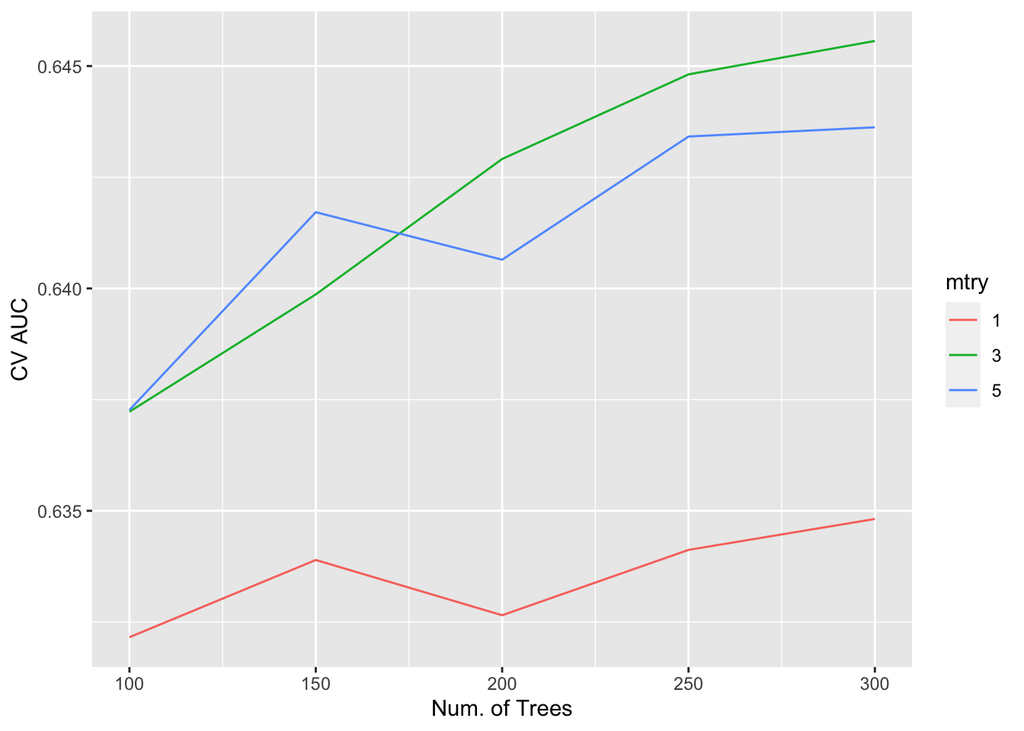

```r
rf_fit %>%
  collect_metrics() %>%
  print(width = Inf) %>%
  filter(.metric == "roc_auc") %>%
  mutate(mtry = as.factor(mtry)) %>%
  ggplot(mapping = aes(x = trees, y = mean, color = mtry)) +
  # geom_point() +
  geom_line() +
  labs(x = "Num. of Trees", y = "CV AUC")
```

```r
rf_fit %>%
  show_best("roc_auc")
```

```
# A tibble: 5 × 8
   mtry trees .metric .estimator  mean     n std_err .config
  <int> <int> <chr>   <chr>      <dbl> <int>   <dbl> <chr>
1     3   300 roc_auc binary     0.646     5 0.00322 Preprocessor1_Model14
2     3   250 roc_auc binary     0.645     5 0.00300 Preprocessor1_Model11
3     5   300 roc_auc binary     0.644     5 0.00281 Preprocessor1_Model15
4     5   250 roc_auc binary     0.643     5 0.00268 Preprocessor1_Model12
5     3   200 roc_auc binary     0.643     5 0.00276 Preprocessor1_Model08
```

```r
best_rf <- rf_fit %>%
  select_best("roc_auc")

final_wf <- rf_wf %>%
  finalize_workflow(best_rf)

final_fit <-
  final_wf %>%
  last_fit(data_split)

final_fit %>%
  collect_metrics()
```

```
# A tibble: 2 × 4
  .metric  .estimator .estimate .config
  <chr>    <chr>          <dbl> <chr>
1 accuracy binary         0.600 Preprocessor1_Model1
2 roc_auc  binary         0.641 Preprocessor1_Model1
```

#####boosting

```r
# eval: true
# Preprocessing
mimic_recipe <-
  recipe(
    los_long ~ .,
    data = mimiciv_other
  ) %>%
  step_impute_mean(
sodium, chloride, creatinine, potassium, glucose, hematocrit, wbc, bicarbonate, temperature_f,
non_invasive_blood_pressure_diatolic, non_invasive_blood_pressure_systolic, respiratory_rate, heart_rate,
age_at_intime) %>%
  step_impute_mode(first_careunit, admission_type, admission_location, insurance, language, marital_status,
                   race, gender) %>%
  step_naomit(all_predictors()) %>%
  step_novel(all_nominal_predictors()) %>%
  step_dummy(all_nominal_predictors()) %>%
  step_zv(all_numeric_predictors()) %>%
  step_normalize(all_numeric_predictors())

# Fit the model
gb_mod <-
  boost_tree(
    mode = "classification",
    trees = 1000,
    tree_depth = tune(),
    learn_rate = tune()
  ) %>%
  set_engine("xgboost")

gb_wf <- workflow() %>%
  add_recipe(mimic_recipe) %>%
  add_model(gb_mod)

param_grid <- grid_regular(
  tree_depth(range = c(1L, 3L)),
  learn_rate(range = c(-5, 2), trans = log10_trans()),
  levels = c(3, 10)
  )

set.seed(203)

folds <- vfold_cv(mimiciv_other, v = 5)
gb_fit <- gb_wf %>%
  tune_grid(
    resamples = folds,
    grid = param_grid,
    metrics = metric_set(roc_auc, accuracy),
    control = control_stack_grid()
    )
```

```
ℹ The workflow being saved contains a recipe, which is 5.53 Mb in ℹ memory. If
this was not intentional, please set the control setting ℹ `save_workflow =
FALSE`.
```

```
# A tibble: 60 × 8
   tree_depth learn_rate .metric  .estimator  mean     n std_err
        <int>      <dbl> <chr>    <chr>      <dbl> <int>   <dbl>
 1          1  0.00001   accuracy binary     0.551     5 0.00435
 2          1  0.00001   roc_auc  binary     0.539     5 0.00289
 3          2  0.00001   accuracy binary     0.555     5 0.00172
 4          2  0.00001   roc_auc  binary     0.556     5 0.00344
 5          3  0.00001   accuracy binary     0.561     5 0.00206
 6          3  0.00001   roc_auc  binary     0.572     5 0.00272
 7          1  0.0000599 accuracy binary     0.551     5 0.00435
 8          1  0.0000599 roc_auc  binary     0.539     5 0.00289
 9          2  0.0000599 accuracy binary     0.558     5 0.00338
10          2  0.0000599 roc_auc  binary     0.564     5 0.00555
   .config
   <chr>
 1 Preprocessor1_Model01
 2 Preprocessor1_Model01
 3 Preprocessor1_Model02
 4 Preprocessor1_Model02
 5 Preprocessor1_Model03
 6 Preprocessor1_Model03
 7 Preprocessor1_Model04
 8 Preprocessor1_Model04
 9 Preprocessor1_Model05
10 Preprocessor1_Model05
# ℹ 50 more rows
```

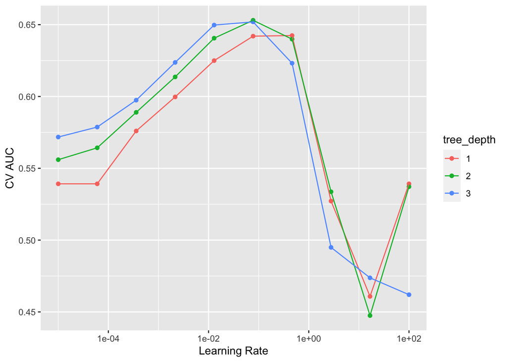

```r
gb_fit %>%
  collect_metrics() %>%
  print(width = Inf) %>%
  filter(.metric == "roc_auc") %>%
  mutate(tree_depth = as.factor(tree_depth)) %>%
  ggplot(mapping = aes(x = learn_rate, y = mean, color = tree_depth)) +
  geom_point() +
  geom_line() +
  labs(x = "Learning Rate", y = "CV AUC") +
  scale_x_log10()
```

```r
gb_fit %>%
  show_best("roc_auc")
```

```
# A tibble: 5 × 8
  tree_depth learn_rate .metric .estimator  mean     n std_err .config
       <int>      <dbl> <chr>   <chr>      <dbl> <int>   <dbl> <chr>
1          2     0.0774 roc_auc binary     0.653     5 0.00439 Preprocessor1_Mo…
2          3     0.0774 roc_auc binary     0.652     5 0.00367 Preprocessor1_Mo…
3          3     0.0129 roc_auc binary     0.650     5 0.00449 Preprocessor1_Mo…
4          1     0.464  roc_auc binary     0.642     5 0.00486 Preprocessor1_Mo…
5          1     0.0774 roc_auc binary     0.642     5 0.00454 Preprocessor1_Mo…
```

```r
best_gb <- gb_fit %>%
  select_best("roc_auc")

final_wf <- gb_wf %>%
  finalize_workflow(best_gb)

final_fit <-
  final_wf %>%
  last_fit(data_split)

final_fit %>%
  collect_metrics()
```

```
# A tibble: 2 × 4
  .metric  .estimator .estimate .config
  <chr>    <chr>          <dbl> <chr>
1 accuracy binary         0.605 Preprocessor1_Model1
2 roc_auc  binary         0.649 Preprocessor1_Model1
```

The model described in the image appears to have been evaluated on two performance metrics: accuracy and ROC AUC (Receiver Operating Characteristic Area Under Curve). The accuracy is approximately 0.6, indicating that the model correctly predicts the outcome about 60% of the time. The ROC AUC score is approximately 0.65, suggesting that the model has a fair ability to distinguish between the classes being predicted.

#####comparison the model of boosting have the best performance in terms of accuracy and ROC AUC.

#####Model Stacking

```r
# eval: true
mimic_model_st <-
  stacks() |>
  add_candidates(tree_fit) |>
  add_candidates(rf_fit) |>
  add_candidates(gb_fit) |>
  blend_predictions(
    penalty = 10^(-6:2),
    metrics = c("roc_auc", "accuracy")
    ) |>
  fit_members()
mimic_model_st
```

```
── A stacked ensemble model ─────────────────────────────────────


Out of 127 possible candidate members, the ensemble retained 15.

Penalty: 0.001.

Mixture: 1.


The 10 highest weighted member classes are:
```

```
# A tibble: 10 × 3
   member                 type        weight
   <chr>                  <chr>        <dbl>
 1 .pred_TRUE_gb_fit_1_17 boost_tree  1.72
 2 .pred_TRUE_rf_fit_1_11 rand_forest 0.946
 3 .pred_TRUE_rf_fit_1_14 rand_forest 0.870
 4 .pred_TRUE_gb_fit_1_18 boost_tree  0.615
 5 .pred_TRUE_rf_fit_1_06 rand_forest 0.395
 6 .pred_TRUE_rf_fit_1_12 rand_forest 0.225
 7 .pred_TRUE_gb_fit_1_21 boost_tree  0.204
 8 .pred_TRUE_rf_fit_1_03 rand_forest 0.188
 9 .pred_TRUE_gb_fit_1_20 boost_tree  0.109
10 .pred_TRUE_gb_fit_1_26 boost_tree  0.0784
```

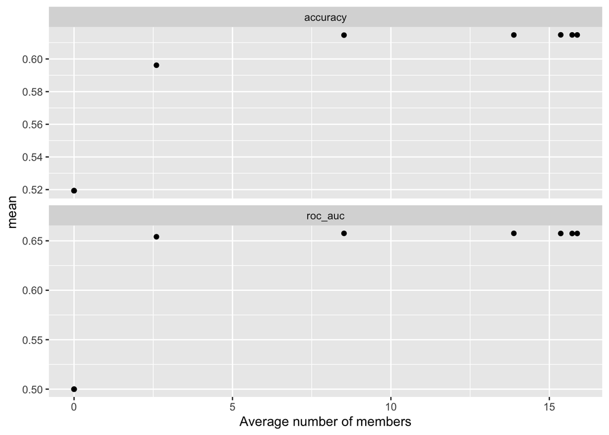

```r
autoplot(mimic_model_st, type = "members")
```

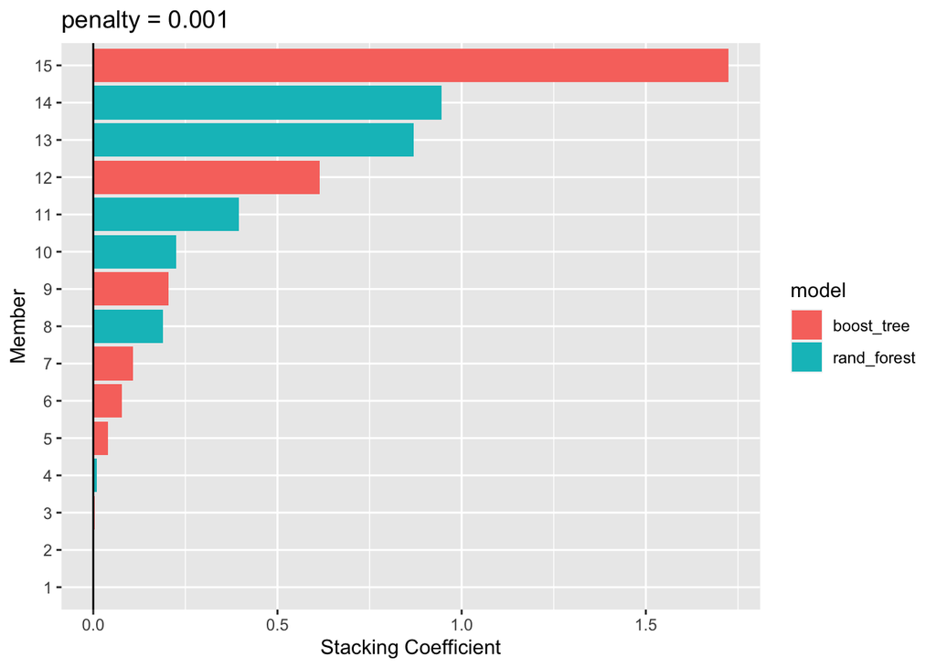

```r
autoplot(mimic_model_st, type = "weights")
```

```r
mimic_auc <- mimiciv_test %>%
  bind_cols(
    predict(mimic_model_st, .,, type = "prob"))%>%
  print(width = Inf)
```

```
# A tibble: 36,591 × 25
   first_careunit                                   admission_type
   <fct>                                            <fct>
 1 Medical Intensive Care Unit (MICU)               EW EMER.
 2 Surgical Intensive Care Unit (SICU)              EW EMER.
 3 Surgical Intensive Care Unit (SICU)              Other
 4 Medical Intensive Care Unit (MICU)               EW EMER.
 5 Medical Intensive Care Unit (MICU)               EW EMER.
 6 Other                                            URGENT
 7 Other                                            URGENT
 8 Medical Intensive Care Unit (MICU)               EW EMER.
 9 Medical/Surgical Intensive Care Unit (MICU/SICU) EW EMER.
10 Medical/Surgical Intensive Care Unit (MICU/SICU) URGENT
   admission_location     insurance language marital_status race  gender
   <fct>                  <chr>     <chr>    <chr>          <fct> <fct>
```

[output cut: 59 more lines]

```r
roc_auc <- yardstick::roc_auc(
  data = mimic_auc,
  truth = los_long,
  contains( ".pred_FALSE")
)

mimic_acc <- mimiciv_test %>%
  bind_cols(
    predict(mimic_model_st, new_data = mimiciv_test)%>%
  print(width = Inf)
    )
```

```
# A tibble: 36,591 × 1
   .pred_class
   <fct>
 1 FALSE
 2 FALSE
 3 FALSE
 4 TRUE
 5 TRUE
 6 TRUE
 7 TRUE
 8 FALSE
 9 TRUE
10 TRUE
# ℹ 36,581 more rows
```

```r
roc_accuracy <- yardstick::accuracy(
  data = mimic_acc,
  truth = "los_long",
  estimate = .pred_class
)


roc_auc
```

```
# A tibble: 1 × 3
  .metric .estimator .estimate
  <chr>   <chr>          <dbl>
1 roc_auc binary         0.655
```

```r
roc_accuracy
```

```
# A tibble: 1 × 3
  .metric  .estimator .estimate
  <chr>    <chr>          <dbl>
1 accuracy binary         0.612
```